# Examen Final - Patinetas Electricas

Felipe Clement

2019-04-07

# Resultados

- `season`: Factor (niveles 1 - 4) que indica la temporada del año: 1 -> primavera, 2 -> verano, 3 -> otoño, 4 -> invierno
- `yr`: Factor (niveles 0 y 1) indicando el año en el cual ha estado operando el sistema: 0 -> 2011, 1 -> 2012
- `holiday`: Factor (niveles 0 y 1) que indica si el día dado es un festivo: 0 -> no festivo, 1 -> festivo
- `weekday`: Factor (niveles 0 - 7) que indica el día de la semana: 0 - 7 -> domigo - sabado
- `weathersit`: Factor (niveles 1 - 4) que indican la situación del clima
- `temp`: Temperatura en grados celcius del día
- `hum`: Humedad relativa en el día
- `windspeed`: Velocidad del viento en el día

Entre estas, se encuentra que las variables mas relevantes (en orden) son `yr` y `temp`. De este resultado, podemos intuir que tiene sentido que el año sea la variable mas relevante, pues mediante pasa el tiempo, se espera que las empresas que operan bajo esta modalidad logren una mayor penetración del mercado. Por otro lado, la temperatura del día es la segunda variable mas relevante, esta a su vez tendría sentido que dependa de como cambia el clima durante el año.

# Procedimiento

Para llegar a los resultados anteriores, se realizó una limpieza a los datos, seguido de una selección automatica de modelo, analisis de supuestos y finalmente un calculo de los coeficientes mas relevantes.

## Exploración de los datos

### Limpieza

```r
data_raw <- read.csv("data.csv")
str(data_raw)
```

```
## 'data.frame':    731 obs. of  16 variables:
##  $ instant   : int  1 2 3 4 5 6 7 8 9 10 ...
##  $ dteday    : Factor w/ 731 levels "2011-01-01","2011-01-02",..: 1 2 3 4 5 6 7 8 9 10 ...
##  $ season    : int  1 1 1 1 1 1 1 1 1 1 ...
##  $ yr        : int  0 0 0 0 0 0 0 0 0 0 ...
##  $ mnth      : int  1 1 1 1 1 1 1 1 1 1 ...
##  $ holiday   : int  0 0 0 0 0 0 0 0 0 0 ...
##  $ weekday   : int  6 0 1 2 3 4 5 6 0 1 ...
##  $ workingday: int  0 0 1 1 1 1 1 0 0 1 ...
##  $ weathersit: int  2 2 1 1 1 1 2 2 1 1 ...
##  $ temp      : num  0.344 0.363 0.196 0.2 0.227 ...
##  $ atemp     : num  0.364 0.354 0.189 0.212 0.229 ...
##  $ hum       : num  0.806 0.696 0.437 0.59 0.437 ...
##  $ windspeed : num  0.16 0.249 0.248 0.16 0.187 ...
##  $ casual    : int  331 131 120 108 82 88 148 68 54 41 ...
##  $ registered: int  654 670 1229 1454 1518 1518 1362 891 768 1280 ...
##  $ cnt       : int  985 801 1349 1562 1600 1606 1510 959 822 1321 ...
```

```r
head(data_raw, 20)
```

```
##    instant     dteday season yr mnth holiday weekday workingday weathersit
## 1        1 2011-01-01      1  0    1       0       6          0          2
## 2        2 2011-01-02      1  0    1       0       0          0          2
## 3        3 2011-01-03      1  0    1       0       1          1          1
## 4        4 2011-01-04      1  0    1       0       2          1          1
## 5        5 2011-01-05      1  0    1       0       3          1          1
## 6        6 2011-01-06      1  0    1       0       4          1          1
## 7        7 2011-01-07      1  0    1       0       5          1          2
## 8        8 2011-01-08      1  0    1       0       6          0          2
## 9        9 2011-01-09      1  0    1       0       0          0          1
## 10      10 2011-01-10      1  0    1       0       1          1          1
## 11      11 2011-01-11      1  0    1       0       2          1          2
## 12      12 2011-01-12      1  0    1       0       3          1          1
## 13      13 2011-01-13      1  0    1       0       4          1          1
## 14      14 2011-01-14      1  0    1       0       5          1          1
```

[output cut: 27 more lines]

Los datos contienen columnas `instant` y `dteday` que indican el indice del registro, carecen de significado semantico, las removeremos.

```r
data_1 <- data_raw[, -which(colnames(data_raw) %in% c("instant", "dteday"))]
str(data_1)
```

```
## 'data.frame':    731 obs. of  14 variables:
##  $ season    : int  1 1 1 1 1 1 1 1 1 1 ...
##  $ yr        : int  0 0 0 0 0 0 0 0 0 0 ...
##  $ mnth      : int  1 1 1 1 1 1 1 1 1 1 ...
##  $ holiday   : int  0 0 0 0 0 0 0 0 0 0 ...
##  $ weekday   : int  6 0 1 2 3 4 5 6 0 1 ...
##  $ workingday: int  0 0 1 1 1 1 1 0 0 1 ...
##  $ weathersit: int  2 2 1 1 1 1 2 2 1 1 ...
##  $ temp      : num  0.344 0.363 0.196 0.2 0.227 ...
##  $ atemp     : num  0.364 0.354 0.189 0.212 0.229 ...
##  $ hum       : num  0.806 0.696 0.437 0.59 0.437 ...
##  $ windspeed : num  0.16 0.249 0.248 0.16 0.187 ...
##  $ casual    : int  331 131 120 108 82 88 148 68 54 41 ...
##  $ registered: int  654 670 1229 1454 1518 1518 1362 891 768 1280 ...
##  $ cnt       : int  985 801 1349 1562 1600 1606 1510 959 822 1321 ...
```

Convertimos las variables necesarias a factores:

- season, yr, month, holiday, weekday, workingday, weathersit: int -> factor

```r
data_1$season <- as.factor(data_1$season)
data_1$yr <- as.factor(data_1$yr)
data_1$mnth <- as.factor(data_1$mnth)
data_1$holiday <- as.factor(data_1$holiday)
data_1$weekday <- as.factor(data_1$weekday)
data_1$workingday <- as.factor(data_1$workingday)
data_1$weathersit <- as.factor(data_1$weathersit)
str(data_1)
```

```
## 'data.frame':    731 obs. of  14 variables:
##  $ season    : Factor w/ 4 levels "1","2","3","4": 1 1 1 1 1 1 1 1 1 1 ...
##  $ yr        : Factor w/ 2 levels "0","1": 1 1 1 1 1 1 1 1 1 1 ...
##  $ mnth      : Factor w/ 12 levels "1","2","3","4",..: 1 1 1 1 1 1 1 1 1 1 ...
##  $ holiday   : Factor w/ 2 levels "0","1": 1 1 1 1 1 1 1 1 1 1 ...
##  $ weekday   : Factor w/ 7 levels "0","1","2","3",..: 7 1 2 3 4 5 6 7 1 2 ...
##  $ workingday: Factor w/ 2 levels "0","1": 1 1 2 2 2 2 2 1 1 2 ...
##  $ weathersit: Factor w/ 3 levels "1","2","3": 2 2 1 1 1 1 2 2 1 1 ...
##  $ temp      : num  0.344 0.363 0.196 0.2 0.227 ...
##  $ atemp     : num  0.364 0.354 0.189 0.212 0.229 ...
##  $ hum       : num  0.806 0.696 0.437 0.59 0.437 ...
##  $ windspeed : num  0.16 0.249 0.248 0.16 0.187 ...
##  $ casual    : int  331 131 120 108 82 88 148 68 54 41 ...
##  $ registered: int  654 670 1229 1454 1518 1518 1362 891 768 1280 ...
##  $ cnt       : int  985 801 1349 1562 1600 1606 1510 959 822 1321 ...
```

Convertimos las variables numericas para que sean interpretables:

- temp: temp*(tM-tm) + tm, tm = -8, tM = 39
- atemp: atemp*(tM-tm) + tm, tm = -16, tM = 50
- hum: hum * 100
- windspeed: windspeed * 67

```r
t_min <- -8
t_max <- 39

data_1$temp <- data_1$temp * (t_max - t_min) + t_min

t_min <- -16
t_max <- 50

data_1$atemp <- data_1$atemp * (t_max - t_min) + t_min

data_1$hum <- data_1$hum * 100
data_1$windspeed <- data_1$windspeed * 67

str(data_1)
```

```
## 'data.frame':    731 obs. of  14 variables:
##  $ season    : Factor w/ 4 levels "1","2","3","4": 1 1 1 1 1 1 1 1 1 1 ...
##  $ yr        : Factor w/ 2 levels "0","1": 1 1 1 1 1 1 1 1 1 1 ...
##  $ mnth      : Factor w/ 12 levels "1","2","3","4",..: 1 1 1 1 1 1 1 1 1 1 ...
##  $ holiday   : Factor w/ 2 levels "0","1": 1 1 1 1 1 1 1 1 1 1 ...
##  $ weekday   : Factor w/ 7 levels "0","1","2","3",..: 7 1 2 3 4 5 6 7 1 2 ...
##  $ workingday: Factor w/ 2 levels "0","1": 1 1 2 2 2 2 2 1 1 2 ...
##  $ weathersit: Factor w/ 3 levels "1","2","3": 2 2 1 1 1 1 2 2 1 1 ...
##  $ temp      : num  8.18 9.08 1.23 1.4 2.67 ...
##  $ atemp     : num  7.999 7.347 -3.499 -2 -0.868 ...
##  $ hum       : num  80.6 69.6 43.7 59 43.7 ...
##  $ windspeed : num  10.7 16.7 16.6 10.7 12.5 ...
##  $ casual    : int  331 131 120 108 82 88 148 68 54 41 ...
##  $ registered: int  654 670 1229 1454 1518 1518 1362 891 768 1280 ...
##  $ cnt       : int  985 801 1349 1562 1600 1606 1510 959 822 1321 ...
```

```r
summary(data_1)
```

```
##  season  yr           mnth     holiday weekday workingday weathersit
##  1:181   0:365   1      : 62   0:710   0:105   0:231      1:463
##  2:184   1:366   3      : 62   1: 21   1:105   1:500      2:247
##  3:188           5      : 62           2:104              3: 21
##  4:178           7      : 62           3:104
##                  8      : 62           4:104
##                  10     : 62           5:104
##                  (Other):359           6:105
##       temp            atemp              hum          windspeed
##  Min.   :-5.221   Min.   :-10.781   Min.   : 0.00   Min.   : 1.500
##  1st Qu.: 7.843   1st Qu.:  6.298   1st Qu.:52.00   1st Qu.: 9.042
##  Median :15.422   Median : 16.124   Median :62.67   Median :12.125
##  Mean   :15.283   Mean   : 15.307   Mean   :62.79   Mean   :12.763
##  3rd Qu.:22.805   3rd Qu.: 24.168   3rd Qu.:73.02   3rd Qu.:15.625
##  Max.   :32.498   Max.   : 39.499   Max.   :97.25   Max.   :34.000
##
##      casual         registered        cnt
##  Min.   :   2.0   Min.   :  20   Min.   :  22
##  1st Qu.: 315.5   1st Qu.:2497   1st Qu.:3152
##  Median : 713.0   Median :3662   Median :4548
##  Mean   : 848.2   Mean   :3656   Mean   :4504
##  3rd Qu.:1096.0   3rd Qu.:4776   3rd Qu.:5956
##  Max.   :3410.0   Max.   :6946   Max.   :8714
##
```

## Supuestos Parte 1

### Multicolinealidad perfecta

Revisaremos primero multicolinealidad perfecta

```r
alias(lm(cnt ~ ., data = data_1))
```

```
## Model :
## cnt ~ season + yr + mnth + holiday + weekday + workingday + weathersit +
##     temp + atemp + hum + windspeed + casual + registered
##
## Complete :
##             (Intercept) season2 season3 season4 yr1 mnth2 mnth3 mnth4
## workingday1  0           0       0       0       0   0     0     0
##             mnth5 mnth6 mnth7 mnth8 mnth9 mnth10 mnth11 mnth12 holiday1
## workingday1  0     0     0     0     0     0      0      0     -1
##             weekday1 weekday2 weekday3 weekday4 weekday5 weekday6
## workingday1  1        1        1        1        1        0
##             weathersit2 weathersit3 temp atemp hum windspeed casual
## workingday1  0           0           0    0     0   0         0
##             registered
## workingday1  0
```

Observamos que existe multicolinealidad perfecta entre `workingday` y `weekday`, procedemos a eliminar `workingday`, pues esta puede ser calculada por la combinacion lineal de `weekday` y `holiday`.

```r
data_2 <- data_1[, -which(colnames(data_1) == "workingday")]
str(data_2)
```

```
## 'data.frame':    731 obs. of  13 variables:
##  $ season    : Factor w/ 4 levels "1","2","3","4": 1 1 1 1 1 1 1 1 1 1 ...
##  $ yr        : Factor w/ 2 levels "0","1": 1 1 1 1 1 1 1 1 1 1 ...
##  $ mnth      : Factor w/ 12 levels "1","2","3","4",..: 1 1 1 1 1 1 1 1 1 1 ...
##  $ holiday   : Factor w/ 2 levels "0","1": 1 1 1 1 1 1 1 1 1 1 ...
##  $ weekday   : Factor w/ 7 levels "0","1","2","3",..: 7 1 2 3 4 5 6 7 1 2 ...
##  $ weathersit: Factor w/ 3 levels "1","2","3": 2 2 1 1 1 1 2 2 1 1 ...
##  $ temp      : num  8.18 9.08 1.23 1.4 2.67 ...
##  $ atemp     : num  7.999 7.347 -3.499 -2 -0.868 ...
##  $ hum       : num  80.6 69.6 43.7 59 43.7 ...
##  $ windspeed : num  10.7 16.7 16.6 10.7 12.5 ...
##  $ casual    : int  331 131 120 108 82 88 148 68 54 41 ...
##  $ registered: int  654 670 1229 1454 1518 1518 1362 891 768 1280 ...
##  $ cnt       : int  985 801 1349 1562 1600 1606 1510 959 822 1321 ...
```

Las variables `casual`, `registered` y `cnt` tambien producen multicolinealidad perfecta pues `casual` + `registered` = `cnt`, eliminamos ambas columnas, pues su efecto es capturado en `cnt`

```r
data <- data_2[, -which(colnames(data_2) %in% c("casual", "registered"))]
str(data)
```

```
## 'data.frame':    731 obs. of  11 variables:
##  $ season    : Factor w/ 4 levels "1","2","3","4": 1 1 1 1 1 1 1 1 1 1 ...
##  $ yr        : Factor w/ 2 levels "0","1": 1 1 1 1 1 1 1 1 1 1 ...
##  $ mnth      : Factor w/ 12 levels "1","2","3","4",..: 1 1 1 1 1 1 1 1 1 1 ...
##  $ holiday   : Factor w/ 2 levels "0","1": 1 1 1 1 1 1 1 1 1 1 ...
##  $ weekday   : Factor w/ 7 levels "0","1","2","3",..: 7 1 2 3 4 5 6 7 1 2 ...
##  $ weathersit: Factor w/ 3 levels "1","2","3": 2 2 1 1 1 1 2 2 1 1 ...
##  $ temp      : num  8.18 9.08 1.23 1.4 2.67 ...
##  $ atemp     : num  7.999 7.347 -3.499 -2 -0.868 ...
##  $ hum       : num  80.6 69.6 43.7 59 43.7 ...
##  $ windspeed : num  10.7 16.7 16.6 10.7 12.5 ...
##  $ cnt       : int  985 801 1349 1562 1600 1606 1510 959 822 1321 ...
```

Para probar que no tengamos multicolinealidad perfecta, usamos `summary` y `lm`, donde no sale ninguna advertencia y el R2 no es 1

```r
summary(lm(cnt ~ ., data))
```

```
##
## Call:
## lm(formula = cnt ~ ., data = data)
##
## Residuals:
##     Min      1Q  Median      3Q     Max
## -3944.7  -348.2    63.8   457.4  2912.7
##
## Coefficients:
##              Estimate Std. Error t value Pr(>|t|)
## (Intercept)  2404.811    245.742   9.786  < 2e-16 ***
## season2       884.711    179.492   4.929 1.03e-06 ***
## season3       832.702    213.129   3.907 0.000102 ***
## season4      1575.351    181.001   8.704  < 2e-16 ***
## yr1          2019.735     58.220  34.691  < 2e-16 ***
## mnth2         131.025    143.776   0.911 0.362443
## mnth3         542.828    165.433   3.281 0.001085 **
## mnth4         451.166    247.567   1.822 0.068820 .
## mnth5         735.505    267.628   2.748 0.006145 **
## mnth6         515.405    282.411   1.825 0.068423 .
## mnth7          30.797    313.821   0.098 0.921854
## mnth8         444.949    303.165   1.468 0.142639
## mnth9        1004.173    265.123   3.788 0.000165 ***
## mnth10        519.674    241.554   2.151 0.031787 *
## mnth11       -116.693    230.776  -0.506 0.613257
## mnth12        -89.591    182.214  -0.492 0.623098
## holiday1     -589.697    180.362  -3.270 0.001130 **
## weekday1      212.054    109.494   1.937 0.053187 .
## weekday2      309.528    107.134   2.889 0.003982 **
## weekday3      381.357    107.478   3.548 0.000414 ***
## weekday4      386.343    107.529   3.593 0.000350 ***
## weekday5      436.984    107.439   4.067 5.30e-05 ***
## weekday6      440.459    106.562   4.133 4.01e-05 ***
## weathersit2  -462.538     77.087  -6.000 3.16e-09 ***
## weathersit3 -1965.087    197.052  -9.972  < 2e-16 ***
## temp           60.745     29.748   2.042 0.041526 *
## atemp          27.063     22.153   1.222 0.222261
## hum           -15.355      2.924  -5.250 2.01e-07 ***
## windspeed     -42.139      6.187  -6.810 2.09e-11 ***
## ---
## Signif. codes:  0 '***' 0.001 '**' 0.01 '*' 0.05 '.' 0.1 ' ' 1
##
## Residual standard error: 769.2 on 702 degrees of freedom
## Multiple R-squared:  0.8484, Adjusted R-squared:  0.8423
## F-statistic: 140.3 on 28 and 702 DF,  p-value: < 2.2e-16
```

## Seleccion del modelo

Utilizaremos seleccion automatica

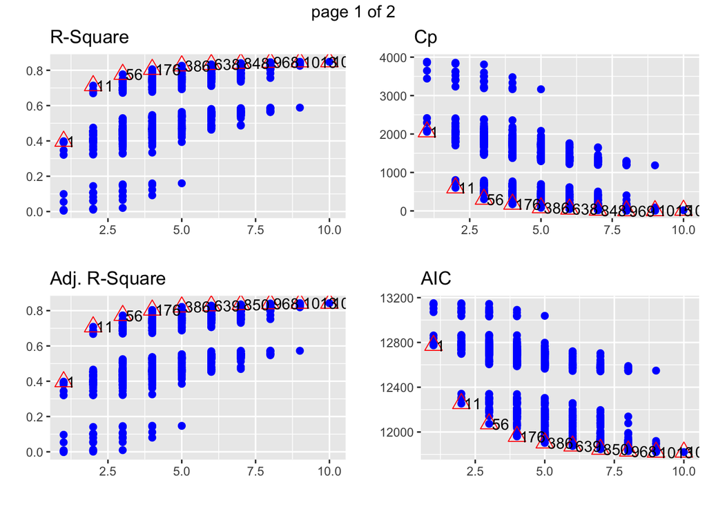

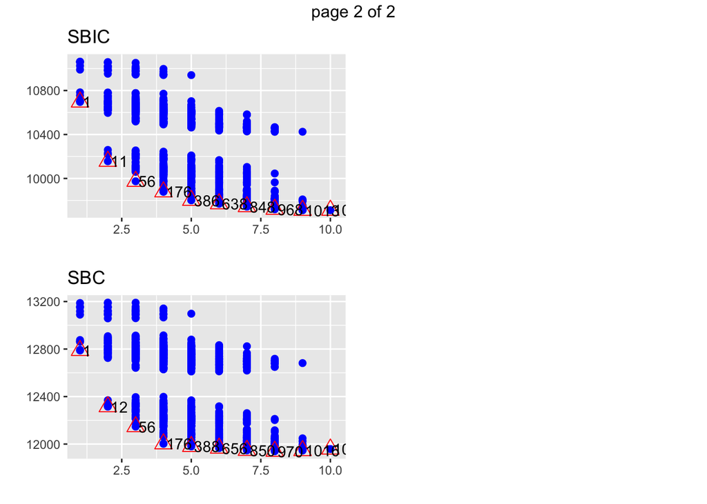

```r
model <- lm(cnt ~ ., data = data)
load("models.RData")
plot(models)
```

Usamos AIC, BIC y r2 ajustado. AIC y R2 ajustado sugieren el modelo usando las variables `season`, `yr`, `mnth`, `holiday`, `weekday`, `weathersit`, `temp`, `hum`, `windspeed`, mientras que BIC sugiere el mismo, sin la variable `weekday`. Compararemos los dos modelos

```r
model_1_vars <- strsplit(models$predictors[which.min(models$aic)], " ")[[1]]
model_2_vars <- strsplit(models$predictors[which.min(models$sbc)], " ")[[1]]
models$predictors[which.max(models$predrsq)]
```

```
## [1] "season yr mnth holiday weekday weathersit temp hum windspeed"
```

Creamos los modelos, no podemos comparar los modelos todavia, pues no hemor validado los supuestos del error.

```r
model_1_formula <- paste("cnt ~", paste(model_1_vars, collapse = " + "))
model_2_formula <- paste("cnt ~", paste(model_2_vars, collapse = " + "))

model_1 <- lm(model_1_formula, data)
model_2 <- lm(model_2_formula, data)

summary(model_1)
```

```
##
## Call:
## lm(formula = model_1_formula, data = data)
##
## Residuals:
##     Min      1Q  Median      3Q     Max
## -3960.9  -350.9    74.1   456.0  2919.9
##
## Coefficients:
##              Estimate Std. Error t value Pr(>|t|)
## (Intercept)  2307.348    232.512   9.924  < 2e-16 ***
## season2       889.302    179.516   4.954 9.12e-07 ***
## season3       832.236    213.204   3.903 0.000104 ***
## season4      1578.947    181.040   8.722  < 2e-16 ***
## yr1          2018.063     58.225  34.660  < 2e-16 ***
## mnth2         136.855    143.747   0.952 0.341396
## mnth3         545.132    165.480   3.294 0.001036 **
## mnth4         456.494    247.615   1.844 0.065667 .
## mnth5         723.520    267.541   2.704 0.007010 **
## mnth6         490.552    281.776   1.741 0.082133 .
## mnth7           8.404    313.395   0.027 0.978613
## mnth8         404.912    301.494   1.343 0.179700
## mnth9         983.948    264.698   3.717 0.000217 ***
## mnth10        520.937    241.636   2.156 0.031432 *
## mnth11       -111.362    230.816  -0.482 0.629621
## mnth12        -84.389    182.229  -0.463 0.643439
## holiday1     -603.605    180.066  -3.352 0.000845 ***
## weekday1      214.877    109.508   1.962 0.050133 .
## weekday2      309.132    107.171   2.884 0.004041 **
## weekday3      377.407    107.467   3.512 0.000473 ***
## weekday4      385.206    107.562   3.581 0.000366 ***
## weekday5      428.604    107.258   3.996 7.12e-05 ***
## weekday6      438.699    106.590   4.116 4.32e-05 ***
## weathersit2  -465.202     77.083  -6.035 2.57e-09 ***
## weathersit3 -1981.357    196.670 -10.075  < 2e-16 ***
## temp           95.475      8.763  10.896  < 2e-16 ***
## hum           -15.182      2.922  -5.196 2.68e-07 ***
## windspeed     -43.663      6.062  -7.202 1.53e-12 ***
## ---
## Signif. codes:  0 '***' 0.001 '**' 0.01 '*' 0.05 '.' 0.1 ' ' 1
##
## Residual standard error: 769.5 on 703 degrees of freedom
## Multiple R-squared:  0.848,  Adjusted R-squared:  0.8422
## F-statistic: 145.3 on 27 and 703 DF,  p-value: < 2.2e-16
```

```r
summary(model_2)
```

```
##
## Call:
## lm(formula = model_2_formula, data = data)
##
## Residuals:
##     Min      1Q  Median      3Q     Max
## -3925.2  -374.6    85.4   487.7  3031.6
##
## Coefficients:
##              Estimate Std. Error t value Pr(>|t|)
## (Intercept)  2675.500    221.751  12.065  < 2e-16 ***
## season2       898.997    181.861   4.943 9.59e-07 ***
## season3       847.395    215.953   3.924 9.56e-05 ***
## season4      1566.511    183.380   8.542  < 2e-16 ***
## yr1          2011.985     58.989  34.108  < 2e-16 ***
## mnth2         139.381    145.676   0.957 0.339000
## mnth3         536.618    167.614   3.202 0.001428 **
## mnth4         423.876    250.513   1.692 0.091079 .
## mnth5         684.725    270.628   2.530 0.011617 *
## mnth6         437.427    284.635   1.537 0.124788
## mnth7         -67.181    316.214  -0.212 0.831813
## mnth8         347.523    304.607   1.141 0.254302
## mnth9         947.379    267.408   3.543 0.000422 ***
## mnth10        512.398    244.506   2.096 0.036468 *
## mnth11        -94.434    233.699  -0.404 0.686272
## mnth12        -71.915    184.503  -0.390 0.696817
## holiday1     -649.392    174.922  -3.712 0.000221 ***
## weathersit2  -429.320     77.623  -5.531 4.48e-08 ***
## weathersit3 -1899.655    197.956  -9.596  < 2e-16 ***
## temp           98.391      8.818  11.158  < 2e-16 ***
## hum           -16.568      2.938  -5.638 2.48e-08 ***
## windspeed     -44.318      6.137  -7.221 1.33e-12 ***
## ---
## Signif. codes:  0 '***' 0.001 '**' 0.01 '*' 0.05 '.' 0.1 ' ' 1
##
## Residual standard error: 779.9 on 709 degrees of freedom
## Multiple R-squared:  0.8426, Adjusted R-squared:  0.8379
## F-statistic: 180.7 on 21 and 709 DF,  p-value: < 2.2e-16
```

## Supuestos Parte 2

### Heteroscedasticidad

Probaremos promero la normalidad de los errores, para decidir si la prueba de Breusch-Pagan es valida o si debemos usar la version studentizada.

#### Normalidad errores

En todos los casos, para ambos modelos, los errores no siguen una distribucion normal.

```r
ols_test_normality(model_1)
```

```
## -----------------------------------------------
##        Test             Statistic       pvalue
## -----------------------------------------------
## Shapiro-Wilk              0.9524         0.0000
## Kolmogorov-Smirnov        0.0742          6e-04
## Cramer-von Mises         62.4362         0.0011
## Anderson-Darling          7.7146         0.0000
## -----------------------------------------------
```

```r
ols_test_normality(model_2)
```

```
## -----------------------------------------------
##        Test             Statistic       pvalue
## -----------------------------------------------
## Shapiro-Wilk              0.9569         0.0000
## Kolmogorov-Smirnov        0.0701         0.0015
## Cramer-von Mises         62.7392         0.0012
## Anderson-Darling          6.8177         0.0000
## -----------------------------------------------
```

#### Prueba de Breusch-Pagan

En ambos casos, existe heteroscedasticidad.

```r
bptest(model_1)
```

```
##
##  studentized Breusch-Pagan test
##
## data:  model_1
## BP = 75.358, df = 27, p-value = 1.869e-06
```

```r
bptest(model_2)
```

```
##
##  studentized Breusch-Pagan test
##
## data:  model_2
## BP = 65.43, df = 21, p-value = 1.862e-06
```

```r
# TODO
```

### Autocorrelacion

#### Prueba de Rachas

```r
errors_1 <- residuals(model_1)
errors_1_signs <- factor(errors_1 > 0)
runs.test(errors_1_signs)
```

```
##
##  Runs Test
##
## data:  errors_1_signs
## Standard Normal = -7.1779, p-value = 7.079e-13
## alternative hypothesis: two.sided
```

```r
errors_2 <- residuals(model_2)
errors_2_signs <- factor(errors_2 > 0)
runs.test(errors_2_signs)
```

```
##
##  Runs Test
##
## data:  errors_2_signs
## Standard Normal = -8.2139, p-value < 2.2e-16
## alternative hypothesis: two.sided
```

#### Prueba Durbin Watson

Similar a la prueba enterior, esta prueba indica que existe autocorrelacion tipo AR(1) para ambos modelos. No es necesaria la prueba h de Durbin, pues no existe variable explicativa rezagada.

```r
dwtest(model_1)
```

```
##
##  Durbin-Watson test
##
## data:  model_1
## DW = 1.2003, p-value < 2.2e-16
## alternative hypothesis: true autocorrelation is greater than 0
```

```r
dwtest(model_2)
```

```
##
##  Durbin-Watson test
##
## data:  model_2
## DW = 1.2163, p-value < 2.2e-16
## alternative hypothesis: true autocorrelation is greater than 0
```

#### Prueba Box-Pirece

Similar a la prueba enterior, esta prueba indica que existe autocorrelacion tipo AR(1) para ambos modelos. No es necesaria la prueba de Ljung-Box, pues la muestra es mayor a 20.

```r
Box.test(errors_1)
```

```
##
##  Box-Pierce test
##
## data:  errors_1
## X-squared = 116.77, df = 1, p-value < 2.2e-16
```

```r
Box.test(errors_2)
```

```
##
##  Box-Pierce test
##
## data:  errors_2
## X-squared = 112.15, df = 1, p-value < 2.2e-16
```

#### Prueba de Breusch-Godfrey

Similar a la prueba enterior, esta prueba indica que existe autocorrelacion tipo AR(1) para ambos modelos.

```r
bgtest(model_1)
```

```
##
##  Breusch-Godfrey test for serial correlation of order up to 1
##
## data:  model_1
## LM test = 118.1, df = 1, p-value < 2.2e-16
```

```r
bgtest(model_2)
```

```
##
##  Breusch-Godfrey test for serial correlation of order up to 1
##
## data:  model_2
## LM test = 114.12, df = 1, p-value < 2.2e-16
```

### Correccion para heteroscedasticidad y autocorrelacion

Utilizamos los 3 metodos HAC para re estimar la matriz de varianzas y covarianzas de los coeficientes y poder comparar los dos modelos candidato.

```r
cov_matrix_nw <- NeweyWest(model_1)
cov_matrix_an <- kernHAC(model_1)
cov_matrix_lh <- weave(model_1)
```

Comparamos los dos modelos mediante una prueba de Wald donde `H0: modelo restringido`. Para todas las pruebas, podemos rechazar la `H0` de que el modelo restringido es mejor, por lo tanto, se escoge el modelo con la variable `weekday` (model_1).

```r
waldtest(model_2, model_1, vcov = cov_matrix_nw)
```

```
## Wald test
##
## Model 1: cnt ~ season + yr + mnth + holiday + weathersit + temp + hum +
##     windspeed
## Model 2: cnt ~ season + yr + mnth + holiday + weekday + weathersit + temp +
##     hum + windspeed
##   Res.Df Df      F    Pr(>F)
## 1    709
## 2    703  6 5.3669 1.968e-05 ***
## ---
## Signif. codes:  0 '***' 0.001 '**' 0.01 '*' 0.05 '.' 0.1 ' ' 1
```

```r
waldtest(model_2, model_1, vcov = cov_matrix_an)
```

```
## Wald test
##
## Model 1: cnt ~ season + yr + mnth + holiday + weathersit + temp + hum +
##     windspeed
## Model 2: cnt ~ season + yr + mnth + holiday + weekday + weathersit + temp +
##     hum + windspeed
##   Res.Df Df      F    Pr(>F)
## 1    709
## 2    703  6 5.6359 9.939e-06 ***
## ---
## Signif. codes:  0 '***' 0.001 '**' 0.01 '*' 0.05 '.' 0.1 ' ' 1
```

```r
waldtest(model_2, model_1, vcov = cov_matrix_lh)
```

```
## Wald test
##
## Model 1: cnt ~ season + yr + mnth + holiday + weathersit + temp + hum +
##     windspeed
## Model 2: cnt ~ season + yr + mnth + holiday + weekday + weathersit + temp +
##     hum + windspeed
##   Res.Df Df      F    Pr(>F)
## 1    709
## 2    703  6 4.1597 0.0004057 ***
## ---
## Signif. codes:  0 '***' 0.001 '**' 0.01 '*' 0.05 '.' 0.1 ' ' 1
```

```r
model <- model_1
```

### Multicolinealidad

#### VIF

Se calcularan los VIF para cada uno de los coeficientes del modelo.

```r
vif(model)
```

```
##                  GVIF Df GVIF^(1/(2*Df))
## season     169.713093  3        2.352985
## yr           1.046249  1        1.022863
## mnth       391.715048 11        1.311784
## holiday      1.116829  1        1.056801
## weekday      1.153293  6        1.011956
## weathersit   1.886133  2        1.171907
## temp         7.006223  1        2.646927
## hum          2.135348  1        1.461283
## windspeed    1.221500  1        1.105215
```

El VIF para el coeficiente de las variables `mnth` y `season` son de 391 y 169 respectivamente, estos valores son muy altos, se calculara el valor Kappa del modelo.

#### Kappa

El valor de esta prueba da 1651, que es muy grande, removeremos `mnth` y probaremos si se reduce el problema de multicolinealidad.

```r
calculate_kappa <- function(mod) {
  X <- model.matrix(mod)
  eigenvalues <- eigen(t(X) %*% X)

  eigen_max <- max(eigenvalues$val)
  eigen_min <- min(eigenvalues$val)

  return(sqrt(eigen_max/eigen_min))
}

calculate_kappa(model)
```

```
## [1] 1651.162
```

#### Solucion

Se observa que eliminando `mnth` todos los VIF de los coeficientes son menores que 4, lo cual parece indicar que no hay multicolinealidad, sin embargo, el valor de la prueba Kappa sigue siendo 611.

Si eliminamos el siguente valor el VIF mas grande `season`, todos los coeficientes tendrán un VIF menor a 2, y el valor de la prueba Kappa no disminuye demasiado (607). Por este motivo, basta con eliminar solamente `mnth` ya que el efecto de tratarr de reducir mas el valor de la prueba Kappa es marginal y todos los VIF son menores a 4.

```r
model_res_1 <- lm(cnt ~ season + yr + holiday + weekday + weathersit + temp + hum + windspeed, data)
vif(model_res_1)
```

```
##                GVIF Df GVIF^(1/(2*Df))
## season     3.542400  3        1.234666
## yr         1.031355  1        1.015556
## holiday    1.091505  1        1.044751
## weekday    1.132319  6        1.010409
## weathersit 1.828189  2        1.162801
## temp       3.413793  1        1.847645
## hum        1.930192  1        1.389313
## windspeed  1.190123  1        1.090927
```

```r
calculate_kappa(model_res_1)
```

```
## [1] 611.3966
```

```r
model_res_2 <- lm(cnt ~ yr + holiday + weekday + weathersit + temp + hum + windspeed, data)
vif(model_res_2)
```

```
##                GVIF Df GVIF^(1/(2*Df))
## yr         1.023698  1        1.011780
## holiday    1.090138  1        1.044097
## weekday    1.128639  6        1.010135
## weathersit 1.792645  2        1.157107
## temp       1.099241  1        1.048447
## hum        1.867494  1        1.366563
## windspeed  1.153364  1        1.073948
```

```r
calculate_kappa(model_res_2)
```

```
## [1] 607.2988
```

```r
model <- model_res_1
```

## Modelo final

Probaremos otra vez los supuestos de heteroscedasticidad y autocorrelacion. Reestimaremos la matriz de varianzas y covarianzas.

### Supuestos

```r
# heteroscedasticidad
bptest(model)
```

```
##
##  studentized Breusch-Pagan test
##
## data:  model
## BP = 63.112, df = 16, p-value = 1.552e-07
```

```r
# autocorrelacion
errors <- residuals(model)
errors_signs <- factor(errors > 0)
runs.test(errors_signs)
```

```
##
##  Runs Test
##
## data:  errors_signs
## Standard Normal = -8.42, p-value < 2.2e-16
## alternative hypothesis: two.sided
```

```r
dwtest(model)
```

```
##
##  Durbin-Watson test
##
## data:  model
## DW = 1.0636, p-value < 2.2e-16
## alternative hypothesis: true autocorrelation is greater than 0
```

```r
Box.test(errors)
```

```
##
##  Box-Pierce test
##
## data:  errors
## X-squared = 159.86, df = 1, p-value < 2.2e-16
```

```r
bgtest(model)
```

```
##
##  Breusch-Godfrey test for serial correlation of order up to 1
##
## data:  model
## LM test = 161.82, df = 1, p-value < 2.2e-16
```

```r
cov_matrix <- weave(model)
```

### Coeficientes resultantes

```r
coeftest(model, vcov = cov_matrix)
```

```
##
## t test of coefficients:
##
##               Estimate Std. Error t value  Pr(>|t|)
## (Intercept)  2180.0629   294.2193  7.4097 3.586e-13 ***
## season2      1139.2546   275.6674  4.1327 4.010e-05 ***
## season3       842.9248   390.4497  2.1589  0.031194 *
## season4      1543.8684   226.0162  6.8308 1.809e-11 ***
## yr1          2017.1364   159.5199 12.6450 < 2.2e-16 ***
## holiday1     -663.7908   208.5807 -3.1824  0.001524 **
## weekday1      210.2680   119.7984  1.7552  0.079657 .
## weekday2      295.7473   123.7671  2.3895  0.017128 *
## weekday3      364.0453   128.0820  2.8423  0.004607 **
## weekday4      388.7288   102.9219  3.7769  0.000172 ***
## weekday5      428.4628   103.8657  4.1252 4.141e-05 ***
## weekday6      441.8438    94.2876  4.6861 3.335e-06 ***
## weathersit2  -450.8949    89.1970 -5.0550 5.474e-07 ***
## weathersit3 -1976.1856   253.5466 -7.7942 2.294e-14 ***
## temp          108.3137    18.2615  5.9313 4.683e-09 ***
## hum           -12.2091     3.8031 -3.2103  0.001386 **
## windspeed     -41.4898     6.5565 -6.3280 4.384e-10 ***
## ---
## Signif. codes:  0 '***' 0.001 '**' 0.01 '*' 0.05 '.' 0.1 ' ' 1
```

## Variable mas relevante

```r
model_s <- lm.beta(model)
coeftest(model_s, vcov = cov_matrix)
```

```
##
## t test of coefficients:
##
##               Estimate Std. Error t value Pr(>|t|)
## (Intercept)   0.000000 294.219305  0.0000   1.0000
## season2       0.255403 275.667401  0.0009   0.9993
## season3       0.190314 390.449655  0.0005   0.9996
## season4       0.342283 226.016187  0.0015   0.9988
## yr1           0.520985 159.519861  0.0033   0.9974
## holiday1     -0.057276 208.580661 -0.0003   0.9998
## weekday1      0.038094 119.798422  0.0003   0.9997
## weekday2      0.053367 123.767076  0.0004   0.9997
## weekday3      0.065691 128.081968  0.0005   0.9996
## weekday4      0.070146 102.921856  0.0007   0.9995
## weekday5      0.077315 103.865682  0.0007   0.9994
## weekday6      0.080049  94.287598  0.0008   0.9993
## weathersit2  -0.110166  89.196983 -0.0012   0.9990
## weathersit3  -0.170518 253.546574 -0.0007   0.9995
## temp          0.481035  18.261470  0.0263   0.9790
## hum          -0.089764   3.803141 -0.0236   0.9812
## windspeed    -0.111206   6.556545 -0.0170   0.9865
```

```r
coef(model_s)[which.max(abs(coef(model_s)))]
```

```
##       yr1
## 0.5209849
```